# 121140068_ho2

### Explanation

Sebelum masuk ke penjelasan, saya akan menjelaskan tentang apa itu Frequencies Resolution. Frequencies Resolution adalah seberapa jelas kita dapat memisahkan sebuah komponen frekuensi dari sebuah sinyal, bisanya di petakan dalam kurun waktu window length (detik)

### Frequencies Resolution

Semakin tinggi sebuah nilai frequency resolution, maka akan semakin sulit untuk membedakan frekuencies yang berdekatan, misalkan untuk window 0.5 detik dengan $f_s$ 2 Hz, maka akan sulit untuk membadakan frekuensi 10 and 12 Hz.

### Trade off frequencies resolution and time resolution.

Kedua hal ini menggunakan window length sebagai media perhitungnan, semakin lama sebuah length window, maka akan semakin baik pula frequencies resolution yang dihasilkan, namun performa dari time resolution akan berkurang, dan sebaliknya.

### Task 3

- Mengapa nyquist_rate dihitung sebagai `sampling_rate / 2`? Dan mengapa frekuensi cutoff (low dan high) dibagi dengan nyquist_rate?

`Nyquist theorem` adalah sebuah pernyataan bahwa untuk mensample sebuah sinyal analog tanpa adanya aliasing, maka jenis frekuensi sampling yang digunakan adalah 2x dari maximum frekuensi yang ada di sinyal tersebut. Disisi lain `nyquist rate` merepresentasikan sinyal yang dapat di representasikan tanpa aliasing (biasanya di sekitar `sampling rate / 2`).

Dengan membagi frekuensi *cutoff* dengan nyquist rate, maka hasil dari frekuensi cutoff yang dihasilkan akan berada pada rentang [0,1] untuk mempermudah proses kalkulasi. Metode filter seperti `scipy.butter` atau `scipy.firwin` dapat berjalan dengan memasukan input berupa target `low / high cutoff` beserta sampling rate nya, jadi tidak perlu repot untuk melakukan perhitungan `nyquist rate`

### Task 4

- Jelaskan apa itu IIR
- Jelaskan bagaimana merancang filter IIR secara manual (tanpa menggunakan `scipy.signal`)
- Lakukan eksperimen dengan membandingkan filter IIR yang dibuat secara manual Vs. menggunakan `scipy.signal`

IIR (Infinite Impuse Response) adalah metode untuk membuat filter dengan menggunakan konsep feedback loops, artinya menggunakan nilai dari input saat ini dan sebelumnya untuk menghitung nilai dari output saat ini. Berbeda dengan `FIR` (Finite Impulse Response) yang menggunakan konvolusi dalam proses perhitungan, `IIR` menggunakan konsep rekursif sehingga prosses yang dilakukan menjadi jauh lebih efektif dibandingkan dengan `FIR`. IIR Filter sendiri dapat dijelaskan dengan formula berikut $$ y[n] = \sum_{k=0}^{M} b_{k}x[n - k] - \sum_{j=1}^{N} a_{j}y[n - j] $$ Dimana:

- x[n] adalah input sinyal
- y[n] adalah output sinyal
- b adalah Feedforwards constant (menggabungkan input saat ini dan sebelumnya)
- a adalah Feedback constant (menggabungkan output sebelumnya.)

### Creating a IIR Low Filter

Untuk menghitung IIR sendiri, ada beberapa langkah yang perlu dilakukan, pertama menentukan koefisien a dan b lalu menghitung dengan formula IIR.

```python
import numpy as np

def butterworth_lowpass_manual(x, cutoff, fs):
    # Normalize the frequency (cutoff in rad/s)
    Wn = 2 * np.pi * cutoff  # Analog cutoff frequency
    T = 1 / fs  # Sampling period

    # Calculate b0, b1, and a1
    b0 = Wn / (2 / T + Wn)
    b1 = b0
    a1 = (2 / T - Wn) / (2 / T + Wn)

    # Normalize the coefficients (by ensuring the gain is 1 at DC)
    b = np.array([b0, b1])  # b coefficients (numerator)
    a = np.array([1, -a1])  # a coefficients (denominator)


    y = np.zeros_like(x)
    for i in range(1, len(x)):
        y[i] = b[0] * x[i] + b[1] * x[i-1] - a[1] * y[i-1]

    return y
```

```python
from scipy.signal import filtfilt, butter

## Scipy IIR Filter
def scipy_iir_filter(x, cutoff, fs):
    b, a = butter(1, cutoff, btype='low', fs=fs)
    print(b, a)
    return filtfilt(b, a, x)
```

```python
# Example signal (sine wave + noise)
fs = 1000  # Sampling frequency (Hz)
t = np.linspace(0, 1, fs, endpoint=False)  # Time array
x = np.sin(2 * np.pi * 50 * t) + 0.5 * np.random.normal(0, 1, fs)  # Signal with noise

# Apply the lowpass IIR filter
cutoff = 30  # Cutoff frequency (Hz)
filtered_signal = butterworth_lowpass_manual(x, cutoff, fs)

## Filter the signal using scipy
filtered_signal_scipy = scipy_iir_filter(x, cutoff, fs)
```

```
[0.08636403 0.08636403] [ 1.         -0.82727195]
```

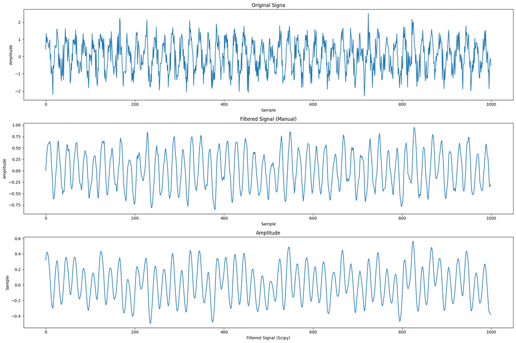

```python
## Visualie the signal and the filtered signal
fig, ax = plt.subplots(3, 1, figsize=(18, 12))
ax[0].plot(x)
ax[0].set_title("Original Signa")
ax[0].set_xlabel("Sample")
ax[0].set_ylabel("Amplitude")

ax[1].plot(filtered_signal)
ax[1].set_title("Filtered Signal (Manual)")
ax[1].set_xlabel("Sample")
ax[1].set_ylabel("Amplitude")

ax[2].plot(filtered_signal_scipy)
ax[2].set_xlabel('Filtered Signal (Scipy)')
ax[2].set_ylabel('Sample')
ax[2].set_title('Amplitude')

plt.tight_layout()
plt.show()
```

### Explanation

Pada kasus ini, terdepat penggunaan 2 metode yakni dengan IIR Filter secara manual dengan dengan `scipy.signal`. Untuk metode manual sendiri ada 2 langkah penting yang perlu dilakukan.

1. Menentukan koefisien a dan b. Disini akan ditentukan koefisien a dan b, di set sebuah variable `Wn` sebagai analog cutoff untuk menentukan frekuensi untuk menghilangkan frekuensi tinggi pada low-pass filter. Analog cutoff sendiri ini di definisikan sebagai $$ W_n = 2 \pi f_{cutoff} $$
2. Sampling period `T` adalah kebalikan dari sampling rate `fs` dimana ini merupakan waktu antara setiap sampel yang di definisikan sebagai $$ T = \frac{1}{f_s} $$
3. Untuk koefisien a1, b0, b1 merupakan nilai past and current values yang digunakan untuk perhitungan IIR filter nanti.

### Task 5

- Jelaskan karakteristik dari filter FIR dan IIR. Apa kelebihan dan kekurangan dari masing-masing filter? FIR Meskipun kedua metode ini menghasilkan filter yang bisa digunakan, namun FIR dan IIR memliki beberapa kelebihan dan kekurangan.

#### FIR

- Respon Impulse Terbatas, FIR tidak memliki feedback layaknya IIR sehingga FIR cenderung stabil di banding IIR
- Waktu proses yang lama, karena proses koefisien FIR yang bergantung pada jumlah sampel, maka waktu komputasi yang dilakukan akan semakin lama karena banyak operasi yang akan dilakukan.
- Desain yang sederhana, desain filter FIR cukup sederhana ketimbang IIR karena melibatkan koefisien filter, mudah untuk di implementasikan

#### IIR

- Respons Impuls Tak Terbatas, IIR memilik respon impuls tak terbatas karena mengandung feedback sebagai variable untuk nilai berikutnya.
- Desain yang lebih kompleks, IIR memiliki desain filter yang lebih kompleks karena mengandung banyak koefisien (koefisien sekarang dan feedback)
- Efisiensi komputasi, Filter IIR lebih efisien dalam hal jumlah koefisien untuk mencapai performa yang sama dibandingkan dengan FIR.
- Stabilitas: IIR bisa menjadi tidak stabil jika tidak dirancang dengan hati-hati, karena adanya umpan balik.

### Task 6

- Buatlah Respiration Signal dengan library `neurokit2`
- Aturlah `noise = 0.2` untuk ECG atau `noise = 0.05` untuk Respiration Signal
- Gunakan NIM (121140068) anda sebagai random seed
- Sampling rate dan durasi signal bebas
- Lakukan komparasi antara filter FIR dan IIR pada sinyal yang telah dibuat. Gunakan `scipy.signal` untuk filter FIR dan IIR agar lebih mudah.
- Lakukan cut off yang menurut anda paling baik untuk kedua filter tersebut dan jelaskan alasannya. (Pernah dibahas di kelas)

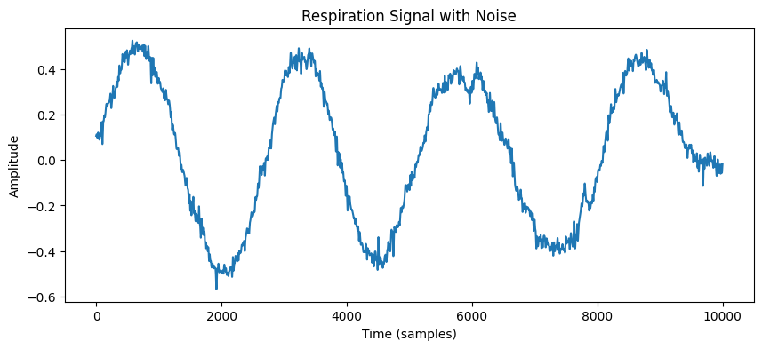

```python
## Setup the respiration signal

import neurokit2 as nk
import matplotlib.pyplot as plt

# Generate respiration signal with noise
duration = 10  # in seconds
sampling_rate = 1000  # in Hz

respiration_signal = nk.rsp_simulate(duration=duration, sampling_rate=sampling_rate, respiratory_rate=20, noise=0.05, random_state=121140068)

# Plot the respiration signal
plt.figure(figsize=(10, 4))
plt.plot(respiration_signal)
plt.title("Respiration Signal with Noise")
plt.xlabel("Time (samples)")
plt.ylabel("Amplitude")
plt.show()
```

```
The most dominant frequency is 0.40 Hz
```

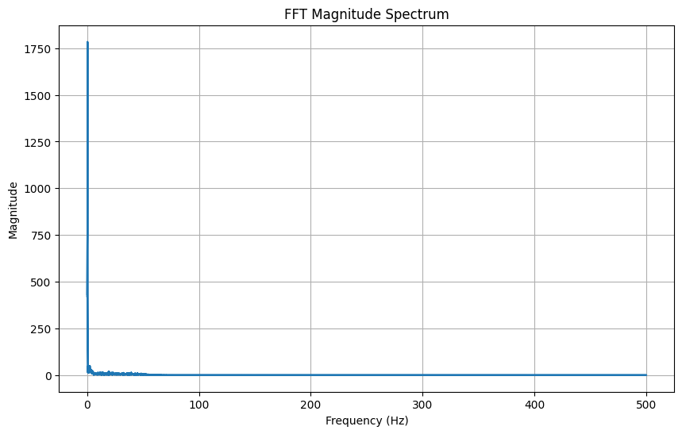

```python
## Visualisasi Frekuensi

# Langkah 1: Hitung Panjang Sinyal
N = len(respiration_signal)

# Langkah 2: Hitung FFT Menggunakan Fungsi FFT SciPy
fft_results = fft.fft(respiration_signal)
fft_magnitude = np.abs(fft_results)  # Get the magnitude of the FFT
fft_freqs = np.fft.fftfreq(len(respiration_signal), 1 / sampling_rate)  # Frequency axis

# Langkah 3: Hitung x-axisnya
freq = fft.fftfreq(N, 1/sampling_rate)

# Menemukan frekuensi dominan
dominant_freq = fft_freqs[np.argmax(fft_magnitude)]
print(f"The most dominant frequency is {dominant_freq:.2f} Hz")

# Plot the FFT magnitude spectrum
plt.figure(figsize=(10, 6))
plt.plot(abs(fft_freqs), fft_magnitude)
plt.xlabel('Frequency (Hz)')
plt.ylabel('Magnitude')
plt.title('FFT Magnitude Spectrum')
plt.grid(True)
plt.show()
```

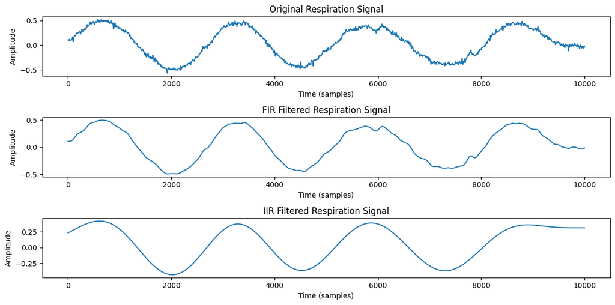

```python
## Filtering

from scipy import signal

# Define cutoff frequency
cutoff = 0.5

# Design FIR filter (low-pass)
fir_order = 101  # Filter order
fir_coeff = signal.firwin(fir_order, cutoff, fs=sampling_rate)

# Apply FIR filter to the respiration signal
fir_filtered = signal.filtfilt(fir_coeff, 1.0, respiration_signal)

# Design IIR filter (low-pass)
iir_b, iir_a = signal.butter(4, cutoff / (0.5 * sampling_rate), btype='low')

# Apply IIR filter to the respiration signal
iir_filtered = signal.filtfilt(iir_b, iir_a, respiration_signal)

# Plot the original and filtered signals
plt.figure(figsize=(12, 6))

# Original signal
plt.subplot(3, 1, 1)
plt.plot(respiration_signal)
plt.title("Original Respiration Signal")
plt.xlabel("Time (samples)")
plt.ylabel("Amplitude")

# FIR filtered signal
plt.subplot(3, 1, 2)
plt.plot(fir_filtered)
plt.title("FIR Filtered Respiration Signal")
plt.xlabel("Time (samples)")
plt.ylabel("Amplitude")

# IIR filtered signal
plt.subplot(3, 1, 3)
plt.plot(iir_filtered)
plt.title("IIR Filtered Respiration Signal")
plt.xlabel("Time (samples)")
plt.ylabel("Amplitude")

plt.tight_layout()
plt.show()
```

### Explanation

Alasan memilih frekuensi cutoff pada 0,5 Hz adalah frekuensi maksimum berapa pada frekuensi 0.4, kita akan melakukkan filter low-pass untuk mengzinkan frekuensi dibawah 0.5 untuk lewat (Filter noise di frekuensi yang lebih tinggi.)

Referensi:

- [3b1b Fourier Transform Video](https://www.youtube.com/watch?v=spUNpyF58BY&t=16s&ab_channel=3Blue1Brown)
- [FFT Tourism SO](https://stackoverflow.com/questions/28009590/understanding-the-radix-2-fft-recursive-algorithm)
- [Intuition behind sampling rates](https://www.youtube.com/watch?v=Jv5FU8oUWEY&list=WL&index=4&ab_channel=ZachStar)